# Practical Machine Learning - Course Project

# Process/Clean Data

Since we need to be able to test the model prior to the submission of this project, the training set will be split into another train/test subset of the data with 70% in the train set and 30% in the test set.

Before doing that the data should be cleaned up.A lot of variables have NA values in their columns. To simplify the data set, those columns with NAs will be removed. Upon review of the training data, the first 5 columns should not be important in predicting the classe variable so those will be removed from the data set. These include time stamps and identification of subjects. Additionally, the near zero variance columns will be removed.

```r
library(rpart)
library(caret)
library(randomForest)
library(rattle)
library(gbm)
training_clean <- training[,colSums(is.na(training))==0]
testing_clean <- testing[,colSums(is.na(training))==0]
training_clean <- training_clean[,-c(1:5)]
testing_clean <- testing_clean[,-c(1:5)]
set.seed(55555)
new_inTrain <- createDataPartition(training_clean$classe, p =0.7, list = FALSE)
new_training <- training_clean[new_inTrain,]
train_testing <- training_clean[-new_inTrain,]
NZV <- nearZeroVar(new_training)
new_training <- new_training[,-NZV]
train_testing<- train_testing[,-NZV]
dim(new_training)
```

```
## [1] 13737    54
```

```r
dim(train_testing)
```

```
## [1] 5885   54
```

# Train Models

To begin with, a classification tree, random forest, and a linear discriminant analysis model will be created.

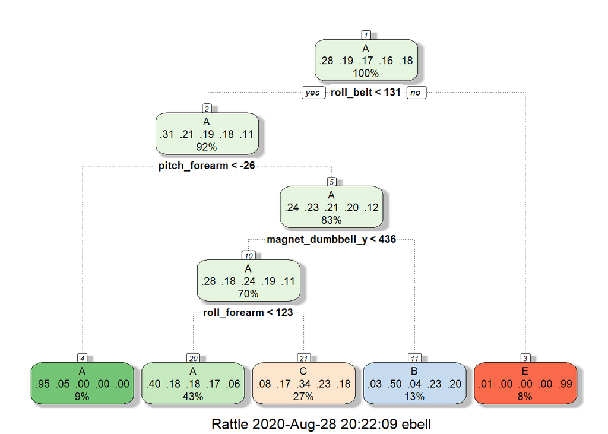

```r
set.seed(44444)
rpart_mod <- train(classe ~., data = new_training, method = "rpart")
fancyRpartPlot(rpart_mod$finalModel)
```

```r
rf_mod <- randomForest(classe ~., data = new_training, trControl = trainControl(method="cv"), number = 3, verboseIter = FALSE)

lda_mod <- train(classe ~., data = new_training, method = "lda", verbose = FALSE)
```

After training the models, the accuracy on the model will be assessed on the training data itself. Afterwards, the models will be assessed for accuracy on the portion of the training set that was set aside for cross validation.

# Accuracy on Training Set

```r
pred_rpart <- predict(rpart_mod, newdata = new_training)
confusionMatrix(pred_rpart, new_training$classe)$overall[1]
```

```
## Accuracy
## 0.495887
```

```r
pred_rf <- predict(rf_mod, newdata = new_training)
confusionMatrix(pred_rf, new_training$classe)$overall[1]
```

```
## Accuracy
##        1
```

```r
pred_lda <- predict(lda_mod, newdata = new_training)
confusionMatrix(pred_lda, new_training$classe)$overall[1]
```

```
##  Accuracy
## 0.7179151
```

```r
predDF <- data.frame(pred_rf,pred_rpart, pred_lda,classe = new_training$classe)
combModFit <- train(classe~., method = "rf", data = predDF,trControl = trainControl(method="cv"), number = 3, verboseIter = FALSE)

combPred <- predict(combModFit , predDF)

confusionMatrix(combPred,new_training$classe)$overall[1]
```

```
## Accuracy
##        1
```

This demonstrates that the random forest and stacked model has the highest accuracy on the training set. The random forest model most likely explains the entire stacked model.  
- Classification Tree: 0.496  
- Random Forest: 1  
- Linear Discriminant Analysis: 0.718  
- Stacked: 1

# Cross Validation

```r
pred_rpart <- predict(rpart_mod, newdata = train_testing)
confusionMatrix(pred_rpart, train_testing$classe)$overall[1]
```

```
## Accuracy
## 0.495497
```

```r
pred_rf <- predict(rf_mod, newdata = train_testing)
confusionMatrix(pred_rf, train_testing$classe)$overall[1]
```

```
##  Accuracy
## 0.9959218
```

```r
pred_lda <- predict(lda_mod, newdata = train_testing)
confusionMatrix(pred_lda, train_testing$classe)$overall[1]
```

```
##  Accuracy
## 0.7087511
```

```r
predDF <- data.frame(pred_rf,pred_rpart, pred_lda,classe = train_testing$classe)
combModFit <- train(classe~., method = "rf", data = predDF,trControl = trainControl(method="cv"), number = 3, verboseIter = FALSE)
combPred <- predict(combModFit , predDF)
confusionMatrix(combPred,train_testing$classe)$overall[1]
```

```
##  Accuracy
## 0.9959218
```

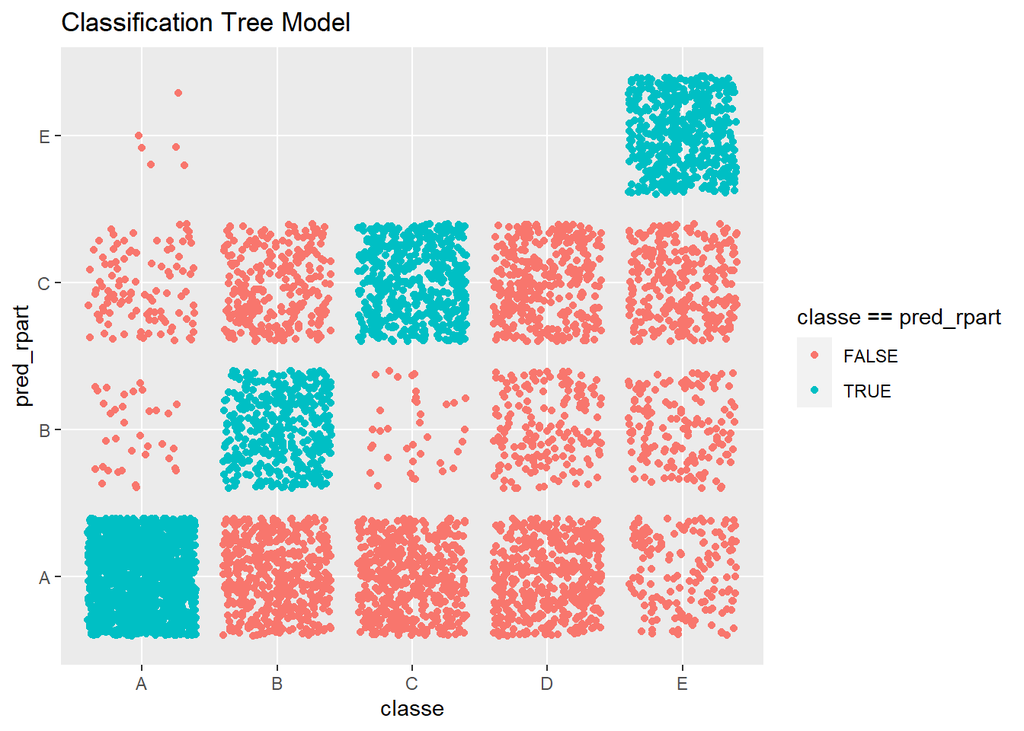

```r
ggplot(train_testing, aes(classe,pred_rpart, color = classe == pred_rpart ))+geom_jitter()+ggtitle("Classification Tree Model")
```

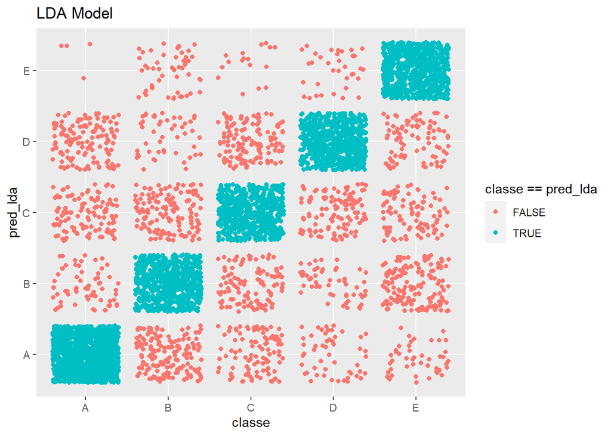

```r
ggplot(train_testing, aes(classe,pred_lda, color = classe == pred_lda ))+geom_jitter()+ggtitle("LDA Model")
```

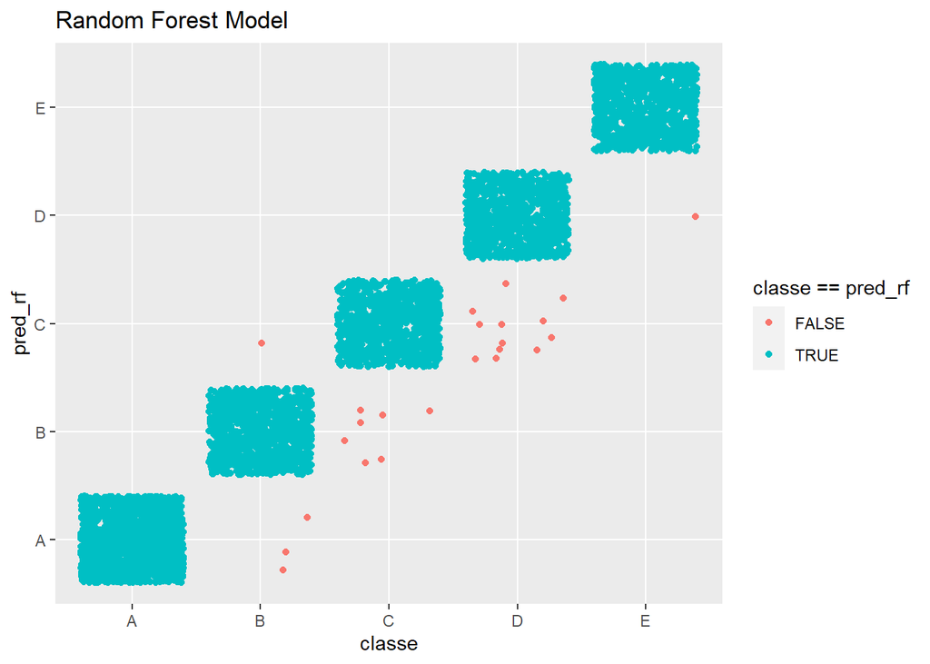

```r
ggplot(train_testing, aes(classe,pred_rf, color = classe == pred_rf ))+geom_jitter()+ggtitle("Random Forest Model")
```

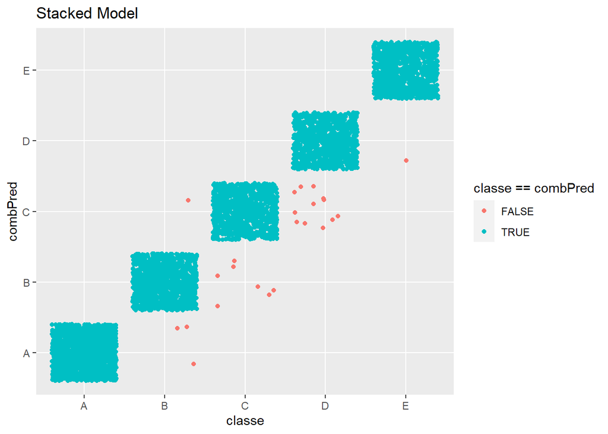

```r
ggplot(train_testing, aes(classe,combPred, color = classe == combPred ))+geom_jitter()+ggtitle("Stacked Model")
```

The plots and accuracy data demonstrates that the random forest and combined model also has the highest accuracy on the cross validation data set. The random forest model will be selected to be tested on the test subject since it is the simpler model.  
- Random Forest: 0.996  
- Linear Discriminant Analsis: 0.709  
- Classification Tree: 0.495  
- Stacked: 0.996